# Size Spectra Method Comparison

Adam A. Kemberling

2021-07-27

```r
showtext::showtext_auto()
```

# Exporatory Data Analysis of NEFSC Bottom Trawl Survey Data

This markdown exsts to highlight differences in size spectrum slopes using different size spectrum binning methods.

- Inidividual Bodymass Spectrum from {sizeSpectra}
- Size Spectrum Slope {mizer}
- Log10 bins

The main differences among methods boil down to a couple of things. Individual Biomass Specctrum vs. normalized biomass-spectra.  
1. Are the biomasses of individuals put into size bins?  
2. How are those bins set?  
3. And how is the linear equation set up with regards to those bins (lef/center/right) aligned

```r
# Loading from targets:
# Load the area-stratified biomass/abundances that used species cutoffs
withr::with_dir(rprojroot::find_root('_targets.R'), tar_load(nefsc_1g))

# Drop columns to speed things up
nefsc_1g <- nefsc_1g %>%
  filter(Year >= 2010) %>%
  select(Year,
         station,
         stratum,
         SpecCode = comname,         #species
         LngtClass = length_cm,        #length
         bodyMass = ind_weight_g,         # lw of individual in grams
         Number = numlen,           # numlen_adj
         bodyMass_sum = sum_weight_g,     # numlen_adj * weight_g
         wmin = wmin_g,             # same as bodymass
         wmax = wmax_g,             # weight of ind at length + 1
         strat_total_abund_s, #stratified abundance
         wmin_area_strat,  # wmin * strat abund
         wmax_area_strat)  #wmax * strat abund
```

## Normalized Biomass-Spectra Approaches

These approaches work by placing the individual biomasses of fishes into discrete bins on a logarithmic scale. The counts within each bin are then plotted, and a linear regression is fit the these bins to get a size spectra slope.

Differences in methodology exist on determining bin structure, bin widths, and normalizing the counts by the width of the bins.

Example:  
In the R package mizer (Scott et al., 2014) the user specifies bins by giving the lower bounds of the smallest and largest bins (min w and max w) and also the number of bins (no w). The bins are equally spaces on the log10() scale, with the last bin of equal width to the second to last bin.

The natural log of counts within each bin are then modeled using a linear regression with the minimum biomass of each bin size used as a predictor to return both a size-spectra slope and an intercept.

### Kathy’s Legacy Code

The methods below area adapted from `cleaned up size spectra code.R`. The code has been streamlined in attempts to clarify the approach.

#### Assigning Bins to the Data

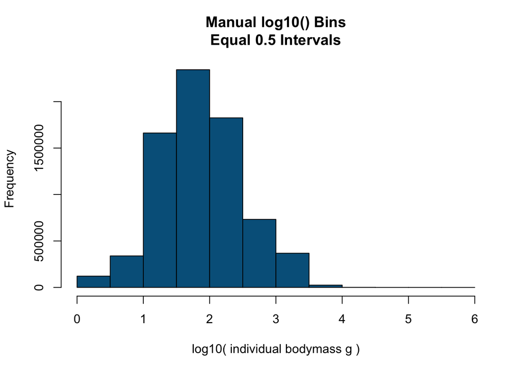

```r
#### 1. Set up bodymass bins


# Copy the data to use for the first method
m1 <- nefsc_1g


# Get bodymass on log10() scale
m1$log10_weight <- log10(m1$bodyMass)


# Set up the bins using 0.5 spacing - Pull min and max from data available
max_bin <- ceiling(max(m1$log10_weight))
min_bin <- floor(min(m1$log10_weight))
n_bins  <- length(seq(max_bin, min_bin + 0.5, by = -0.5))


# Build a bin key, could be used to clean up the incremental assignment or for apply style functions
l10_bin_structure <- data.frame(
  "left_lim"  = seq(max_bin - 0.5, min_bin, by = -0.5),
  "right_lim" = seq(max_bin, min_bin + 0.5, by = -0.5),
  "log10_bins" = as.character(seq(n_bins, 1, by = -1))) %>%
  mutate(
    bin_label = str_c(round(10^left_lim, 3), " - ", round(10^right_lim, 3), "g"),
    bin_width = 10^right_lim - 10^left_lim )



# Loop through bins to assign the bin numbers
m1_assigned <- l10_bin_structure %>%
  split(.$log10_bins) %>%
  map_dfr(function(l10_bin){

    # limits and labels
    l_lim   <- l10_bin$left_lim
    r_lim   <- l10_bin$right_lim
    bin_num <- as.character(l10_bin$log10_bin)

    # assign the label to the appropriate bodymasses
    m1 %>% mutate(
      log10_bins = ifelse( between(log10_weight, l_lim, r_lim), bin_num, NA),
      log10_bins = as.character(log10_bins)) %>%
      drop_na(log10_bins)

  })


# # Old way to do Manual assignment of bins:
# # boxes you in to bins and labels in a lot of text

# m1$log10_bin <- NA
# m1$log10_bin <- ifelse(m1$log10_weight > 2.5, yes = 20, no = m1$log10_bin)
# ...
# ...
# m1$log10_bin <- ifelse(m1$log10_weight >   -7 & m1$log10_weight <= -6.5,  1, m1$log10_bin)




# Plot how they fall in bins

# Get bin breaks
l10_breaks <- sort(unique(c(l10_bin_structure$left_lim, l10_bin_structure$right_lim)))

# Plot
hist(log10(rep(m1$bodyMass, m1$Number)),
     breaks = l10_breaks,
     main = "Manual log10() Bins\nEqual 0.5 Intervals",
     xlab = "log10( individual bodymass g )",
     col = gmri_cols("gmri blue"))
```

#### Plotting the Aggregates

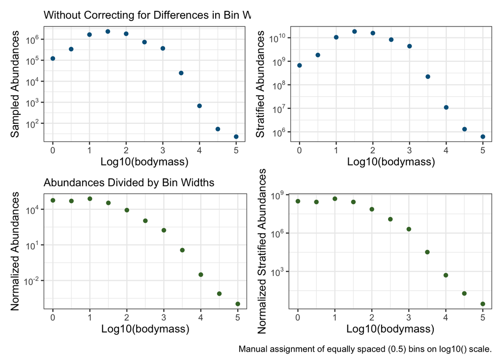

```r
# We already have stratified abundances m1$strat_total_abund_s
# so next we:

# 1. aggregate individual bodymasses into each bin for overall totals

# aggregating all years together
# aggregating all stratum together
m1_aggregates <- m1_assigned %>%
  group_by(log10_bins) %>%
  summarise(years = "all",
            stratum = "all",
            observed_abundance   = sum(Number, na.rm = T),
            observed_weight_g    = sum(wmin, na.rm = T),
            stratified_abundance = sum(strat_total_abund_s, na.rm = T),
            stratified_weight_g  = sum(wmin_area_strat, na.rm = T)) %>%
  ungroup()


# join back in what the limits and labels are
# normalize abundances using bin widths
m1_prepped <- left_join(m1_aggregates, l10_bin_structure, by = "log10_bins") %>%
  mutate(
    normalized_abund = observed_abundance / bin_width,
    norm_strat_abund = stratified_abundance / bin_width)

#### Plotting the Raw Abundances and stratified abundances
abund_plot <- m1_prepped %>%
  ggplot(aes(left_lim, observed_abundance)) +
  geom_point(color = gmri_cols("gmri blue")) +
  scale_y_log10(labels = trans_format("log10", math_format(10^.x))) +
  labs(x = "Log10(bodymass)", y = "Sampled Abundances",
      subtitle = "Without Correcting for Differences in Bin Widths")


strat_abund_plot <- m1_prepped  %>%
  ggplot(aes(left_lim, stratified_abundance)) +
  geom_point(color = gmri_cols("gmri blue")) +
 scale_y_log10(labels = trans_format("log10", math_format(10^.x))) +
  labs(x = "Log10(bodymass)", y = "Stratified Abundances")


raw_plot <- (abund_plot | strat_abund_plot)

#### Plots Correcting for the bin widths
norm_abund_plot <- m1_prepped %>%
  ggplot(aes(left_lim, normalized_abund)) +
  geom_point(color = gmri_cols("green")) +
  scale_y_log10(labels = trans_format("log10", math_format(10^.x))) +
  labs(x = "Log10(bodymass)", y = "Normalized Abundances",
       subtitle = "Abundances Divided by Bin Widths")

norm_strat_abund_plot <- m1_prepped  %>%
  ggplot(aes(left_lim, norm_strat_abund)) +
  geom_point(color = gmri_cols("green")) +
  scale_y_log10(labels = trans_format("log10", math_format(10^.x))) +
  labs(x = "Log10(bodymass)", y = "Normalized Stratified Abundances")


# plots with bin width correction
corrected_plots <- (norm_abund_plot | norm_strat_abund_plot)


# Plot them all together
(raw_plot / corrected_plots) + plot_annotation(caption = "Manual assignment of equally spaced (0.5) bins on log10() scale.")
```

#### Calculate Size-Spectra Slope

```r
# Formula for size spectrum slope
# log10(abundance) ~ log10 bin, aka the minimum bodymass for bin
lm_abund       <- lm(log10(normalized_abund) ~ left_lim, data = m1_prepped)
lm_abund_strat <- lm(log10(norm_strat_abund) ~ left_lim, data = m1_prepped)


# Pull coefficients:

# pull out slope coefficient
# NOTE: Edwards  Subtracts one here, but only for the mizer method, check eightmethods
lm_b <- lm_abund$coeff[2] #- 1
lm_b_strat <- lm_abund_strat$coeff[2] #- 1

# 95% conf
lm_conf = confint(lm_abund, "left_lim", 0.95)
lm_conf_strat = confint(lm_abund_strat, "left_lim", 0.95)




# Storing Model Details:
# this normally populates itself for each method
kathy_results = data.frame(Year = "all",
                           Method = "Manual log10 bins (0.5 increments)",
                           b = lm_b,
                           confMin = lm_conf[1],
                           confMax = lm_conf[2],
                           b_strat = lm_b_strat,
                           confMin_strat = lm_conf_strat[1],
                           confMax_strat = lm_conf_strat[2],
                           row.names = NULL)
```

#### Plotting Slope Fits

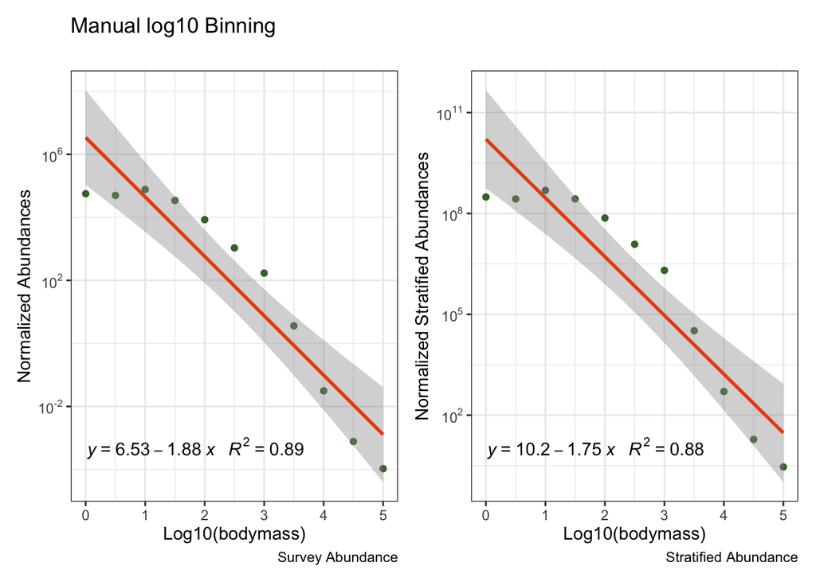

```r
# Abundances from Survey
p1 <- norm_abund_plot +
  geom_smooth(formula = y ~ x,
               method = "lm",
              color = gmri_cols("orange")) +
  stat_poly_eq(formula = y ~ x,
               aes(label = paste(..eq.label.., ..rr.label.., sep = "~~~")),
                   label.y = 0.1,
                   parse = TRUE) +
  labs(caption = "Survey Abundance", subtitle = "", title = "Manual log10 Binning")

# Stratified Abundances
p2 <- norm_strat_abund_plot +
  geom_smooth(formula = y ~ x,
               method = "lm",
              color = gmri_cols("orange")) +
  stat_poly_eq(formula = y ~ x,
               aes(label = paste(..eq.label.., ..rr.label.., sep = "~~~")),
                   label.y = 0.1,
                   parse = TRUE) +
  labs(caption = "Stratified Abundance")


p1 + p2
```

### Mizer

The mizer approach has a few differences from the previous method in terms of bin selection and spacing.

The default number of bins for mizer is 8.

In the R package mizer (Scott et al., 2014) the user specifies bins by giving the lower bounds of the smallest and largest bins (min w and max w) and also the number of bins (no w). The lower bounds of the bins are then calculated as:

`w <- 10^(seq(from = log10(min_w), to = log10(max_w), length_out = no_w)`

Where `min_w` is the minimum individual weight, `max_w`is the maximum individual weight, and `no_w` is the number of bins.

The final bin is then given the same width (on an arithmetic scale) as the penultimate bin (F. Scott, pers. comm). Thus the lower bounds of the bins are equally spaced on a log10 scale, as are the bin widths (except for the final bin).

The counts in each bin are calculated, and the slope of an abundance spectra is calculated as the slope of the linear regression of log(counts) against log(w). There is an option to calculate a biomass spectra, for which counts in each bin are multiplied by the lower bound of that bin, and then the linear regression is performed.

To get into build the bins to match up with how it is done with {mizer}, I dug into the functions of the {sizeSpectra} package that are used to compare methods.The following code will highlight how mizer results look compared to the first method.

#### Assigning Bins to the Data

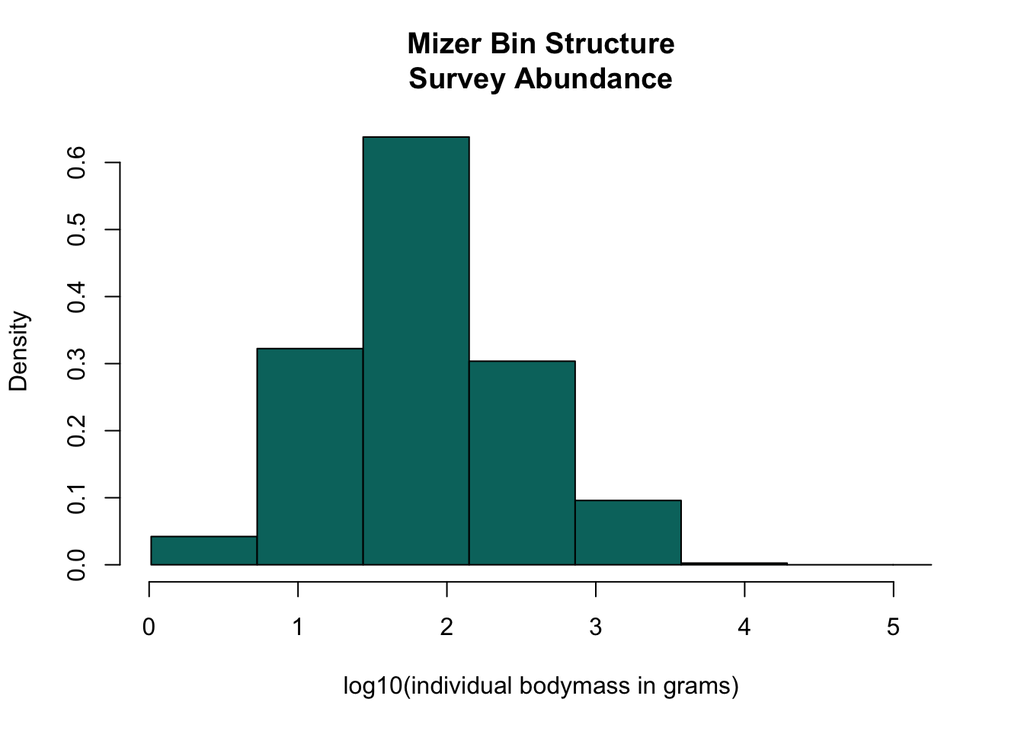

```r
# Copy data for the mizer method
mizer_data <- nefsc_1g

# The following code follows sizeSpectra::eightMethods
# specifically the mizer section

# Vector of Body Sizes
x         <- rep(mizer_data$bodyMass, mizer_data$Number)

log_x     <- log(x)              # take the log
sum_log_x <- sum(log_x)          # total log bodymass
xmin      <- min(x)              # minimum bodymass bin
xmax      <- max(x)              # maximum bodymass bin
num_bins  <- 8                   # default number of bins


# Default bin number k = 8
mizer_num_bins <- num_bins


# Solve for beta (value for equal bin widths) using nlm
beta <- nlm(f    = LBmizbinsFun,
            p    = 2,
            xmin = xmin,
            xmax = xmax,
            k    = mizer_num_bins)$est


# Use beta to get the bin breaks (left side)
mizer_bins = c( beta^(0:(mizer_num_bins - 1)) * min(x), max(x))



####  Getting Counts for stratified abundances
# Just gonna repeat how I did it for the first method because it was helpful


# will make key to use groupby
mizer_bins_key <- data.frame(
  "left_lim"  = mizer_bins[c(1:(length(mizer_bins)-1))],
  "right_lim" = mizer_bins[c(2:length(mizer_bins))],
  "mizer_bin_num" = as.character(seq(num_bins, 1, by = -1))) %>%
  mutate(
    bin_label   = str_c(round(left_lim, 3), " - ", round(right_lim, 3), "g"),
    bin_width_g = right_lim - left_lim)



# Loop through bins to assign the bin numbers
mizer_assigned <- mizer_bins_key %>%
  split(.$mizer_bin_num) %>%
  map_dfr(function(l10_bin){

    # limits and labels
    l_lim   <- l10_bin$left_lim
    r_lim   <- l10_bin$right_lim
    bin_num <- as.character(l10_bin$mizer_bin_num)

    # assign the label to the appropriate bodymasses
    mizer_data %>% mutate(
      mizer_bin_num = ifelse( between(bodyMass, l_lim, r_lim), bin_num, NA)) %>%
      drop_na(mizer_bin_num)

  })




#### Plotting the histogram / get the counts in each bin

# How bin counting is done in eightMethods()
# mizer_bin_hist <- hist(x = x,
#                       breaks = mizer_bins,
#                       plot = F)


# Plot distribution of survey abundances
hist(x = log10(x),
     breaks = log10(mizer_bins),
     main = "Mizer Bin Structure\nSurvey Abundance",
     xlab = "log10(individual bodymass in grams)",
     col = gmri_cols("teal"))
```

#### Plotting the Aggregates

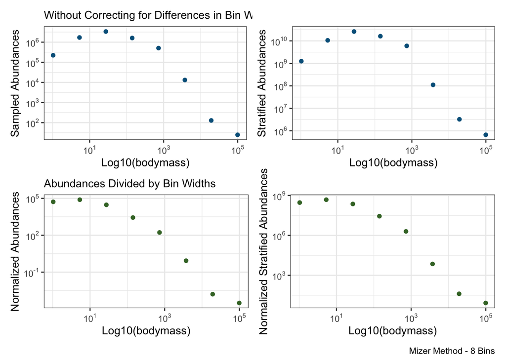

```r
# We already have stratified abundances m1$strat_total_abund_s
# so next we:

# 1. aggregate individual bodymasses into each bin for overall totals

# aggregating all years together
# aggregating all stratum together
# Get totals for the bins
mizer_aggregates <- mizer_assigned %>%
  group_by(mizer_bin_num) %>%
  summarise(years = "all",
            stratum = "all",
            observed_abundance   = sum(Number, na.rm = T),
            observed_weight_g    = sum(wmin, na.rm = T),
            stratified_abundance = sum(strat_total_abund_s, na.rm = T),
            stratified_weight_g  = sum(wmin_area_strat, na.rm = T)) %>%
  ungroup()

# # Do we get the same numbers?-NNO stupic histogram method doesn't work
# sum(mizer_bin_hist$counts)
# sum(mizer_aggregates$observed_abundance)
# sum(mizer_data$Number)
# length(x)

# Verdict
# we lose incomplete numbers of numlen_adj


# join back in what the limits and labels are
# normalize abundances using bin widths
mizer_prepped <- left_join(mizer_aggregates, mizer_bins_key, by = "mizer_bin_num") %>%
  mutate(
    normalized_abund = observed_abundance / bin_width_g,
    norm_strat_abund = stratified_abundance / bin_width_g)

#### Plotting the Raw Abundances and stratified abundances
abund_plot <- mizer_prepped %>%
  ggplot(aes(left_lim, observed_abundance)) +
  geom_point(color = gmri_cols("gmri blue")) +
  scale_x_log10(labels = trans_format("log10", math_format(10^.x))) +
  scale_y_log10(labels = trans_format("log10", math_format(10^.x))) +
  labs(x = "Log10(bodymass)", y = "Sampled Abundances",
      subtitle = "Without Correcting for Differences in Bin Widths")


strat_abund_plot <- mizer_prepped  %>%
  ggplot(aes(left_lim, stratified_abundance)) +
  geom_point(color = gmri_cols("gmri blue")) +
  scale_x_log10(labels = trans_format("log10", math_format(10^.x))) +
  scale_y_log10(labels = trans_format("log10", math_format(10^.x))) +
  labs(x = "Log10(bodymass)", y = "Stratified Abundances")


raw_plot <- (abund_plot | strat_abund_plot)

#### Plots Correcting for the bin widths
norm_abund_plot <- mizer_prepped %>%
  ggplot(aes(left_lim, normalized_abund)) +
  geom_point(color = gmri_cols("green")) +
  scale_x_log10(labels = trans_format("log10", math_format(10^.x))) +
  scale_y_log10(labels = trans_format("log10", math_format(10^.x))) +
  labs(x = "Log10(bodymass)", y = "Normalized Abundances",
       subtitle = "Abundances Divided by Bin Widths")

norm_strat_abund_plot <- mizer_prepped  %>%
  ggplot(aes(left_lim, norm_strat_abund)) +
  geom_point(color = gmri_cols("green")) +
  scale_x_log10(labels = trans_format("log10", math_format(10^.x))) +
  scale_y_log10(labels = trans_format("log10", math_format(10^.x))) +
  labs(x = "Log10(bodymass)", y = "Normalized Stratified Abundances")


# plots with bin width correction
corrected_plots <- (norm_abund_plot | norm_strat_abund_plot)


# Plot them all together
(raw_plot / corrected_plots) + plot_annotation(caption = "Mizer Method - 8 Bins")
```

#### Calculate Size-Spectra Slope

```r
#### How its done in eightMethods:

# Get the log of the mizer bin breaks
mizer_log_min_of_bins <- log(mizer_bins[-length(mizer_bins)])

# getting log of counts - use aggregate totals here and not hist function
mizer_log_counts       <- log(mizer_prepped$observed_abundance) # survey abundance
mizer_log_counts_strat <- log(mizer_prepped$stratified_abundance) # stratified abundance

# Convert inf to NA
mizer_log_counts[is.infinite(mizer_log_counts)] <- NA
mizer_log_counts_strat[is.infinite(mizer_log_counts_strat)] <- NA

# # The order of pairings is getting mismatched when they are added as separate vectors:
# # calculate slope of abundance spectra
# mizer_lm <- lm(mizer_log_counts ~ mizer_log_min_of_bins,
#                na.action = na.omit)
#
# #BONUS: Do the stratified abundances
# mizer_lm_strat <- lm(mizer_log_counts_strat ~ mizer_log_min_of_bins,
#                      na.action = na.omit)
# # pull out slope coefficient
# # NOTE: Edwards  Subtracts 1 here
# mizer_b <- mizer_lm$coeff[2] - 1
# mizer_b_strat <- mizer_lm_strat$coeff[2] - 1
#
# mizer_conf <- confint(mizer_lm, "mizer_log_min_of_bins", 0.95)
# mizer_conf_strat <- confint(mizer_lm_strat, "mizer_log_min_of_bins", 0.95)






####  Fix: Use the mizer_prepped table
# Also, use normalized abundance
mizer_lm       <- lm(log(normalized_abund) ~ log(left_lim),
                     data = mizer_prepped,
                     na.action = na.omit)
mizer_lm_strat <- lm(log(norm_strat_abund) ~ log(left_lim),
                     data = mizer_prepped,
                     na.action = na.omit)



# pull out slope coefficient
# NOTE: Edwards  Subtracts 1 here
mizer_b <- mizer_lm$coeff[2]
mizer_b_strat <- mizer_lm_strat$coeff[2]

# 95% conf
mizer_log_llims <- sort(unique(mizer_prepped$left_lim))
mizer_conf <- confint(mizer_lm, "mizer_log_llims", 0.95)
mizer_conf_strat <- confint(mizer_lm_strat, "mizer_log_min_of_bins", 0.95)


# this normally populates itself for each method
mizer_results <- data.frame(Year          = "all",
                            Method        = "Mizer",
                            b             = mizer_b,
                            confMin       = mizer_conf[1],
                            confMax       = mizer_conf[2],
                            b_strat       = mizer_b_strat,
                            confMin_strat = mizer_conf_strat[1],
                            confMax_strat = mizer_conf_strat[2],
                            row.names     = NULL)
```

#### Plotting the Slope Fits

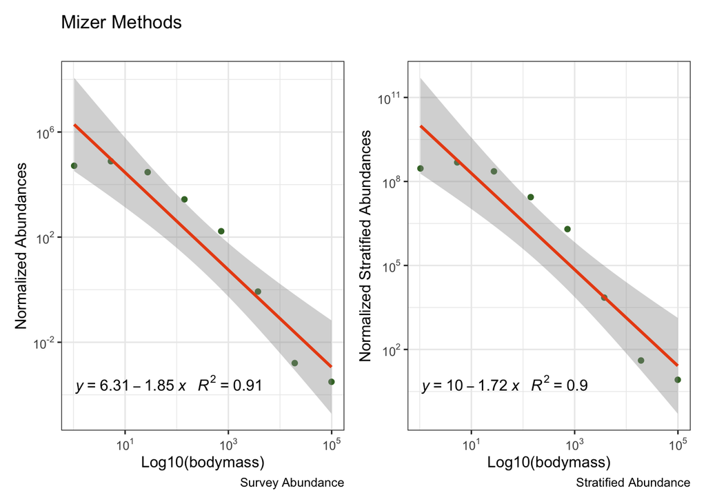

```r
# Abundances from Survey
p1 <- norm_abund_plot +
  geom_smooth(formula = y ~ x,
               method = "lm",
              color = gmri_cols("orange")) +
  stat_poly_eq(formula = y ~ x,
               aes(label = paste(..eq.label.., ..rr.label.., sep = "~~~")),
                   label.y = 0.1,
                   parse = TRUE) +
  labs(caption = "Survey Abundance", subtitle = "", title = "Mizer Methods")

# Stratified Abundances
p2 <- norm_strat_abund_plot +
  geom_smooth(formula = y ~ x,
               method = "lm",
              color = gmri_cols("orange")) +
  stat_poly_eq(formula = y ~ x,
               aes(label = paste(..eq.label.., ..rr.label.., sep = "~~~")),
                   label.y = 0.1,
                   parse = TRUE) +
  labs(caption = "Stratified Abundance")


p1 + p2
```

### sizeSpectra

#### Calculating b

**Survey Abundance**

I have moved these steps into a function to clean up my code, but will step through them here for transparency.

```r
# Set aside data for this last method
dataBin <- nefsc_1g


# Set bodymass lower limit
# subjective
mass_cutoff <- 0 #grams

# Filter for lower end of gear selectivity
dbin_trunc <- filter(dataBin, wmin >= mass_cutoff)

# Create Grouping Var (year/year and season etc.)
dbin_trunc <- dbin_trunc %>%
  mutate(group_var = "all_data")


####  1. Survey Abundance Curves  ####
# The steps of the droup_mle_calc() function are laid out explicitly here
# the same steps are done for stratified abundance numbers below

# Select the necessary columns
dataBinForLike = dplyr::select(dbin_trunc,
                               SpecCode,
                               wmin,
                               wmax,
                               Number)

# Set n, xmin, xmax for power law bounds
n    = sum(dataBinForLike$Number)
xmin = min(dataBinForLike$wmin)
xmax = max(dataBinForLike$wmax)



# Get the likelihood calculation for the bins
# previously named MLEbins.nSeaFung.new
mle_group_bins = calcLike(negLL.fn = negLL.PLB.bins.species,
                          p = -1.9,
                          vecDiff = 0.5,
                          suppress.warnings = TRUE,
                          dataBinForLike = dataBinForLike,
                          n = n,
                          xmin = xmin,
                          xmax = xmax)


# Store outputs in a dataframe
mle_survey_abund = data.frame(xmin = xmin,
                              xmax = xmax,
                              n = n,
                              b = mle_group_bins$MLE,
                              confMin = mle_group_bins$conf[1],
                              confMax = mle_group_bins$conf[2]) %>%
  mutate(group_var = "all years",
         stdErr = (abs(confMin - b) + abs(confMax - b)) / (2 * 1.96),
         C = (b != -1 ) * (b + 1) / ( xmax^(b + 1) - xmin^(b + 1) ) + (b == -1) * 1 / ( log(xmax) - log(xmin)))
```

**Stratified Abundance**

The only difference here is that instead of number at length from the survey we pass the expected area stratified abundances.

```r
# Same code, just behind a function and using stratified abundance instead of numlen for numbers at length

# changed the functions so we'll need the normal names here
dbin_trunc_renamed <- dbin_trunc %>%
  rename(numlen = Number,
         comname = SpecCode,
         length_cm = LngtClass,
         wmin_g = wmin,
         wmax_g = wmax)

#### 2,  stratified abundances:
mle_stratified <- group_mle_calc(dataBinForLike = dbin_trunc_renamed,
                                 group_var = "all data",
                                 abundance_vals = "stratified",
                                 vecDiff = 0.5)



# Put results together
mle_results <- data.frame(Year          = "all",
                          Method        = "sizeSpectra mle",
                          b             = mle_survey_abund$b,
                          confMin       = mle_survey_abund$confMin,
                          confMax       = mle_survey_abund$confMin,
                          b_strat       = mle_stratified$b,
                          confMin_strat = mle_stratified$confMin,
                          confMax_strat = mle_stratified$confMax,
                          row.names     = NULL)
```

#### Individual Size Distribution

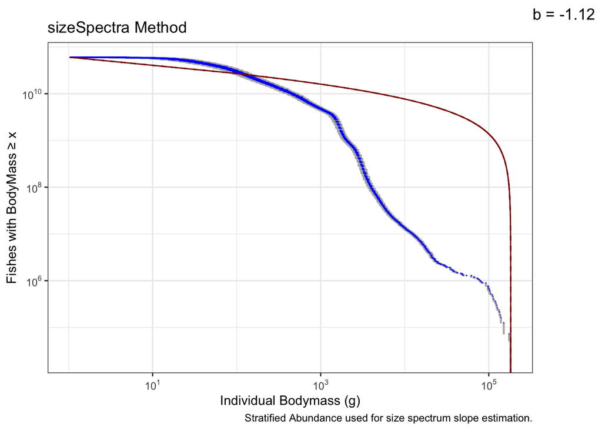

```r
# Breaks - need to revisit the functions

# # Take each group and generate the plots
# isd_group_prepped <- dbin_trunc %>%
#   split(.$group_var) %>%
#   map(isd_plot_prep, stratified_abundance = T)

group_isd_prep <- isd_plot_prep(biomass_data = dbin_trunc_renamed,
                                stratified_abundance = T, min_weight_g = 1)

# Global limits for plot
xlim.global <- c(0, max(dbin_trunc_renamed$wmax_g) )

# Vector of years, for naming
group_names <- sort(unique(dbin_trunc_renamed$group_var))


# # Plot the group
group_isd <- ggplot_isd(isd_data_prepped = group_isd_prep,
                         mle_results = mle_stratified,
                         abundance_vals = "stratified",
                         plot_rects = TRUE,
                         show_pl_fit = T, group_name = "sizeSpectra Method")




# # Take a peak
group_isd$log10_y
```

## Results Comparison

```r
# Put results together
all_results <- bind_rows(kathy_results,  mizer_results, mle_results)


# mess around with tables
all_results %>%
  select(-Year) %>%
  gt() %>%
    tab_header(title = "SS Results for Different Methods",
               subtitle = "Agreement (with minor differences) across methods.") %>%
  fmt_number( # A column (numeric data)
    columns = vars(b, confMin, confMax,
                   b_strat, confMin_strat, confMax_strat),
    decimals = 2) %>%
  cols_label(b = "b (slope)", b_strat = "b (stratified abundance)")
```

SS Results for Different Methods

| Method | b (slope) | confMin | confMax | b (stratified abundance) | confMin_strat | confMax_strat |
| --- | --- | --- | --- | --- | --- | --- |
| Manual log10 bins (0.5 increments) | −1.88 | −2.39 | −1.38 | −1.75 | −2.24 | −1.25 |
| Mizer | −1.85 | NA | NA | −1.72 | NA | NA |
| sizeSpectra mle | −1.15 | −1.15 | −1.15 | −1.12 | −1.12 | −1.12 |